# Customizing GGplots

9/28/2020

## setting graphical parameters

- up until now we have been using the default graphical parameters.
- graphical parameters include axis names, legend size/orientation, plot titles, grid lines etc
- all graphical parameters can be set with the `theme` function.
- lets take a look at the `theme` [documentation](https://ggplot2.tidyverse.org/reference/theme.html)
- all the `theme_...` functions we’ve been using are preset configurations of a theme

## An aside on theme’s and graphical parameters

- while there is a bit of consistency on how to use and change different graphical parameters, much of it will feel a little arbitrary, and there’s no good way to learn how to change them with out trial and error/practice

## Simple Theme modifiers

- There are several functions that allow you to modify specific elements, designed for simplicity
- `xlab`/`ylab` - change the axis labels
- `ggtitle` - add a title to a plot
- `xlim`/`ylim` - change axis limits

## Simple Theme modifiers

```r
data(mpg)
mpg
```

```
## # A tibble: 234 × 11
##    manufacturer model    displ  year   cyl trans   drv     cty   hwy fl    class
##    <chr>        <chr>    <dbl> <int> <int> <chr>   <chr> <int> <int> <chr> <chr>
##  1 audi         a4         1.8  1999     4 auto(l… f        18    29 p     comp…
##  2 audi         a4         1.8  1999     4 manual… f        21    29 p     comp…
##  3 audi         a4         2    2008     4 manual… f        20    31 p     comp…
##  4 audi         a4         2    2008     4 auto(a… f        21    30 p     comp…
##  5 audi         a4         2.8  1999     6 auto(l… f        16    26 p     comp…
##  6 audi         a4         2.8  1999     6 manual… f        18    26 p     comp…
##  7 audi         a4         3.1  2008     6 auto(a… f        18    27 p     comp…
##  8 audi         a4 quat…   1.8  1999     4 manual… 4        18    26 p     comp…
##  9 audi         a4 quat…   1.8  1999     4 auto(l… 4        16    25 p     comp…
## 10 audi         a4 quat…   2    2008     4 manual… 4        20    28 p     comp…
## # … with 224 more rows
```

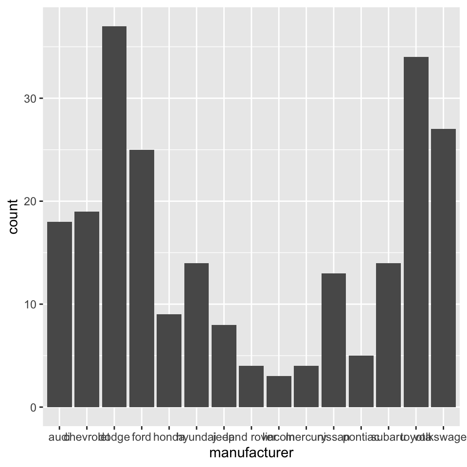

```r
ggplot(mpg) + # standard plot
  geom_bar(aes(x=manufacturer))
```

## Simple Theme modifiers

- change axis labels , and add a title

```r
data(mpg)
mpg
```

```
## # A tibble: 234 × 11
##    manufacturer model    displ  year   cyl trans   drv     cty   hwy fl    class
##    <chr>        <chr>    <dbl> <int> <int> <chr>   <chr> <int> <int> <chr> <chr>
##  1 audi         a4         1.8  1999     4 auto(l… f        18    29 p     comp…
##  2 audi         a4         1.8  1999     4 manual… f        21    29 p     comp…
##  3 audi         a4         2    2008     4 manual… f        20    31 p     comp…
##  4 audi         a4         2    2008     4 auto(a… f        21    30 p     comp…
##  5 audi         a4         2.8  1999     6 auto(l… f        16    26 p     comp…
##  6 audi         a4         2.8  1999     6 manual… f        18    26 p     comp…
##  7 audi         a4         3.1  2008     6 auto(a… f        18    27 p     comp…
##  8 audi         a4 quat…   1.8  1999     4 manual… 4        18    26 p     comp…
##  9 audi         a4 quat…   1.8  1999     4 auto(l… 4        16    25 p     comp…
## 10 audi         a4 quat…   2    2008     4 manual… 4        20    28 p     comp…
## # … with 224 more rows
```

## Simple Theme modifiers

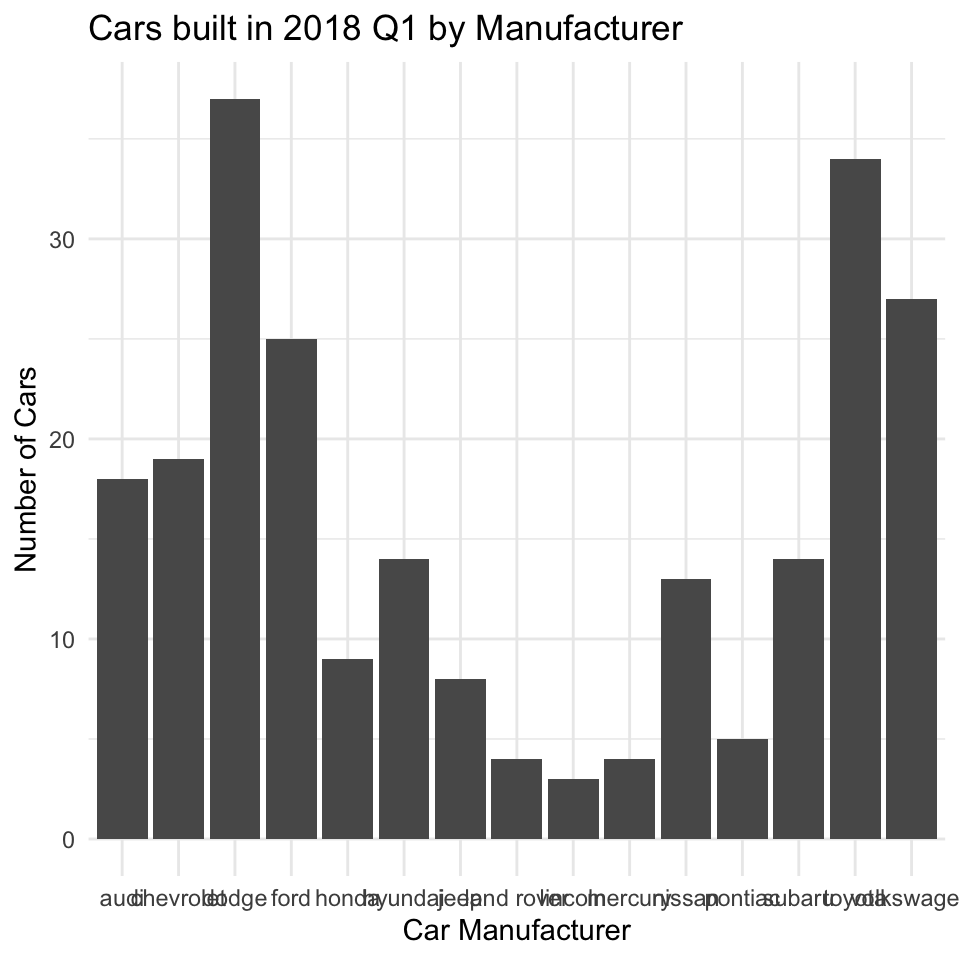

```r
ggplot(mpg) +
  geom_bar(aes(x=manufacturer)) +
  xlab( 'Car Manufacturer' ) +
  ylab( 'Number of Cars' ) +
  ggtitle('Cars built in 2018 Q1 by Manufacturer')+
  theme_minimal()
```

## changing text with `theme`

- we can see in the `theme` function there are multiple inputs for textual parts of the text like `plot.title`, or `axis.text.x`
- there are various setting for text - font, size color etc; These are controlled by the `element_text` function, the output of which we assign to to specific graphical parameter, like `axis.text`.
- these parameters change everything about the text, except the text itself; setting the text is done with functions like `xlab` or `ggtitle` or populated directly from the data

## changing text with `theme`

- the previous plot had squished text on the x axis

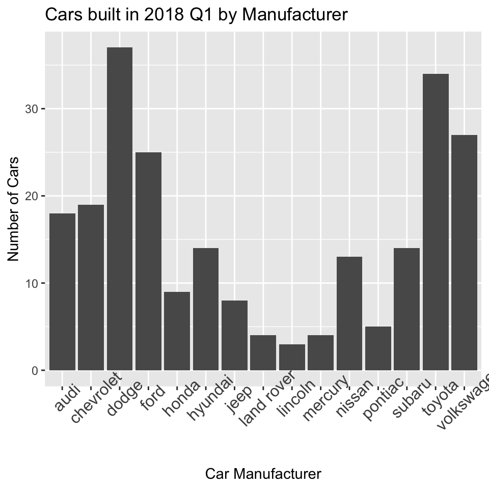

```r
ggplot(mpg) +
  geom_bar(aes(x=manufacturer)) +
  xlab('Car Manufacturer') +
  ylab('Number of Cars' ) +
  ggtitle('Cars built in 2018 Q1 by Manufacturer') +
  theme(axis.text.x = element_text(size = 12, angle = 45))
```

- Note that background of the plot also changed; this is because we were previously using `theme_minimal` which has the background set to white, but in `theme` the default is grey; this can be fixed by combined the two themes

## changing text with `theme`

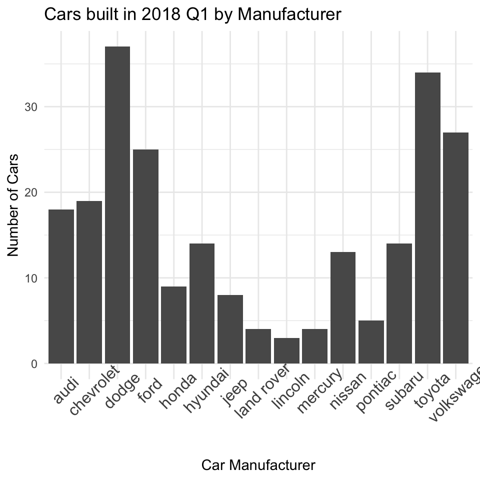

```r
ggplot(mpg) +
  geom_bar(aes(x=manufacturer)) +
  xlab('Car Manufacturer') +
  ylab('Number of Cars' ) +
  ggtitle('Cars built in 2018 Q1 by Manufacturer') +
  theme_minimal()+
  theme(axis.text.x = element_text(size = 12, angle = 45))
```

- the order is important; as each theme is applied in the order it’s added, so adding theme_minimal last can sometimes override changes in the theme made previously

## changing text with `theme`

- while a little better, it would be better if the axis text was off the graph

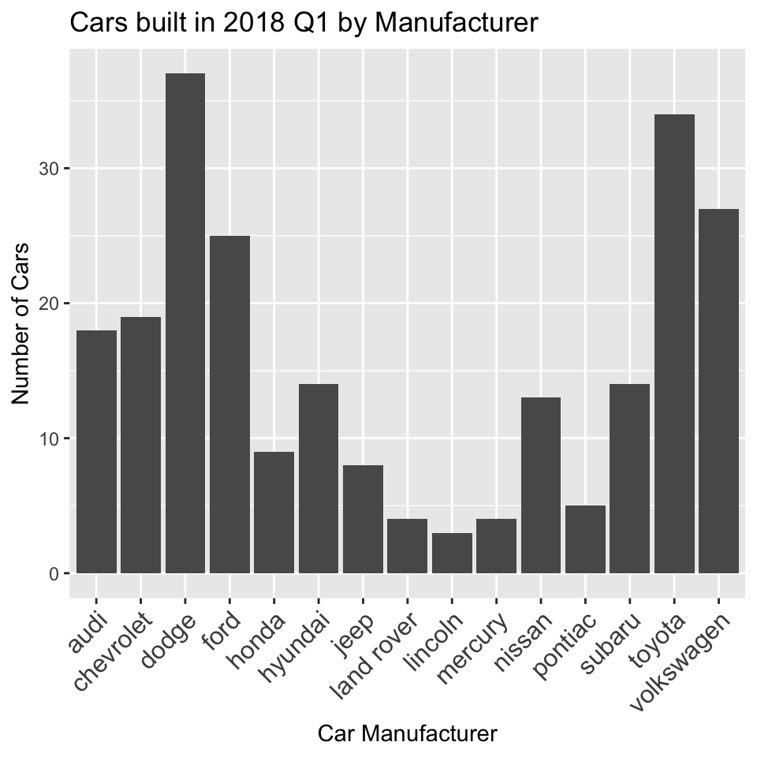

```r
ggplot(mpg) +
  geom_bar(aes(x=manufacturer)) +
  xlab('Car Manufacturer') +
  ylab('Number of Cars' ) +
  ggtitle('Cars built in 2018 Q1 by Manufacturer') +
  theme(axis.text.x = element_text(size = 12, angle = 45, hjust = 1))
```

## setting inheritance

- graphical settings are all linked in a hierarchical manner; for example this is the hierarchy for axis.text.x: `text` > `axis.text` > `axis.text.x` .
- Changing settings for a one parameter changes everything below it in the hierarchy; however, if you specify changes for parameter below it will take precedence over anything set previously

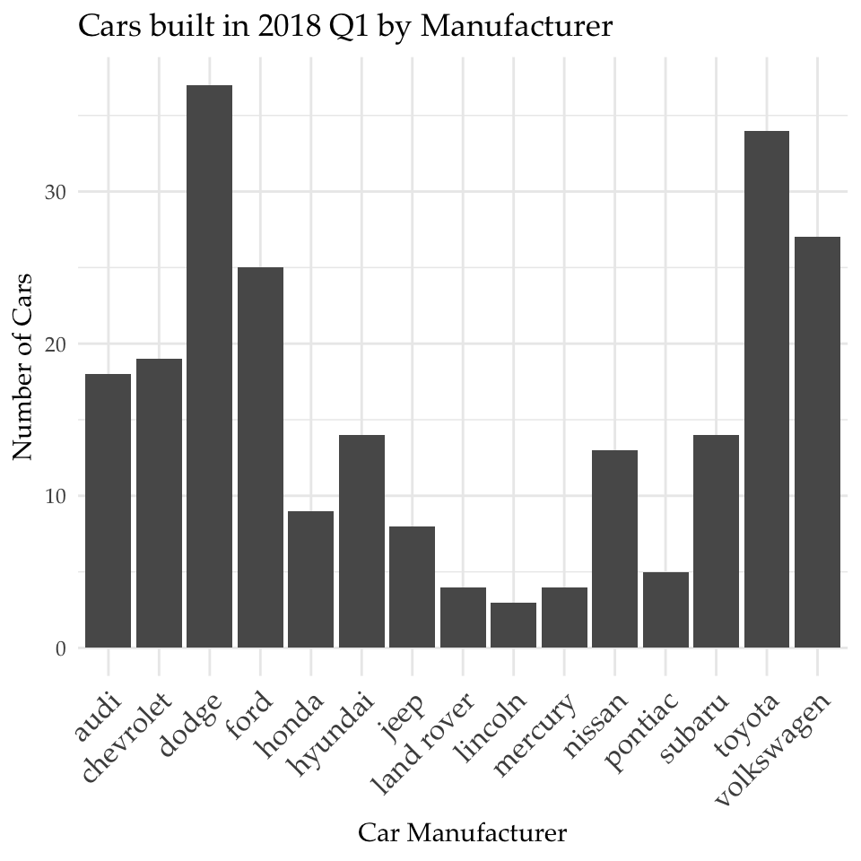

```r
ggplot(mpg) +
  geom_bar(aes(x=manufacturer)) +
  xlab('Car Manufacturer') +
  ylab('Number of Cars' ) +
  ggtitle('Cars built in 2018 Q1 by Manufacturer') +
  theme_minimal()+
  theme(axis.text.x = element_text(size = 12, angle = 45, hjust = 1), text = element_text(family ='Palatino' ))
```

## guides

- guides are an alternative method to setting graphical parameters in theme.
- They were introduced to ggplot after themes, and are generally an easier to use interface for setting graphical parameters, but lack the full range of parameters offered by `theme`

## guides

- For example, what if we want to change the name of the legend in the graph below

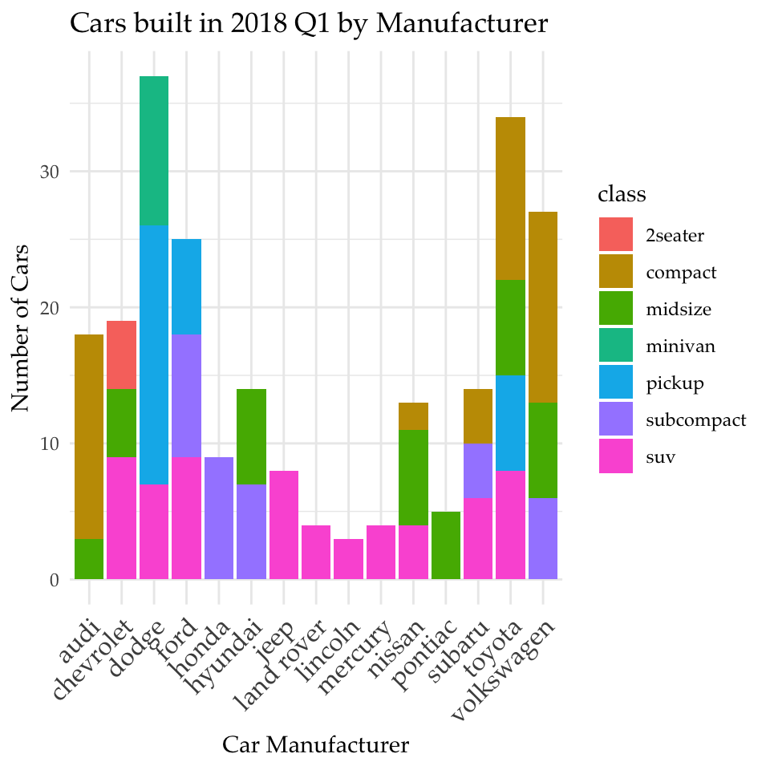

```r
ggplot(mpg) +
  geom_bar(aes(x=manufacturer, fill = class)) +
  xlab('Car Manufacturer') +
  ylab('Number of Cars' ) +
  ggtitle('Cars built in 2018 Q1 by Manufacturer') +
  theme_minimal()+
  theme(axis.text.x = element_text(size = 12, angle = 45, hjust = 1), text = element_text(family ='Palatino' ))
```

## guides

- we have two options:
- option 1. change the name of the `class` column, or make a new column that has the name we want

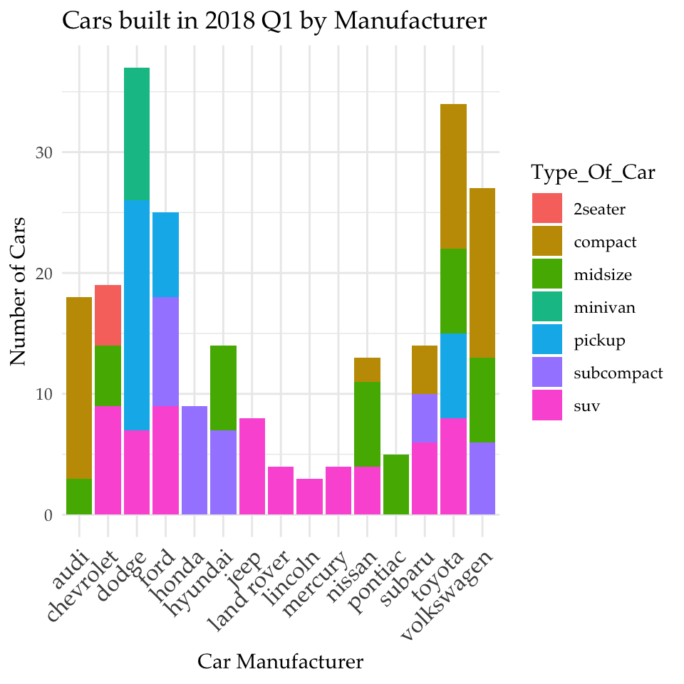

```r
mpg$Type_Of_Car <- mpg$class
ggplot(mpg) +
  geom_bar(aes(x=manufacturer, fill = Type_Of_Car)) +
  xlab('Car Manufacturer') +
  ylab('Number of Cars' ) +
  ggtitle('Cars built in 2018 Q1 by Manufacturer') +
  theme_minimal()+
  theme(axis.text.x = element_text(size = 12, angle = 45, hjust = 1), text = element_text(family ='Palatino' ))
```

## guides

- or option 2, use the `guides` function. For guides we set a value for the aesthetic within the `geom` we want to change , in this case `fill`.
- Next we choose a guide for the graphical parameter associated with that aesthetic we want to change, IE `guide_legend`

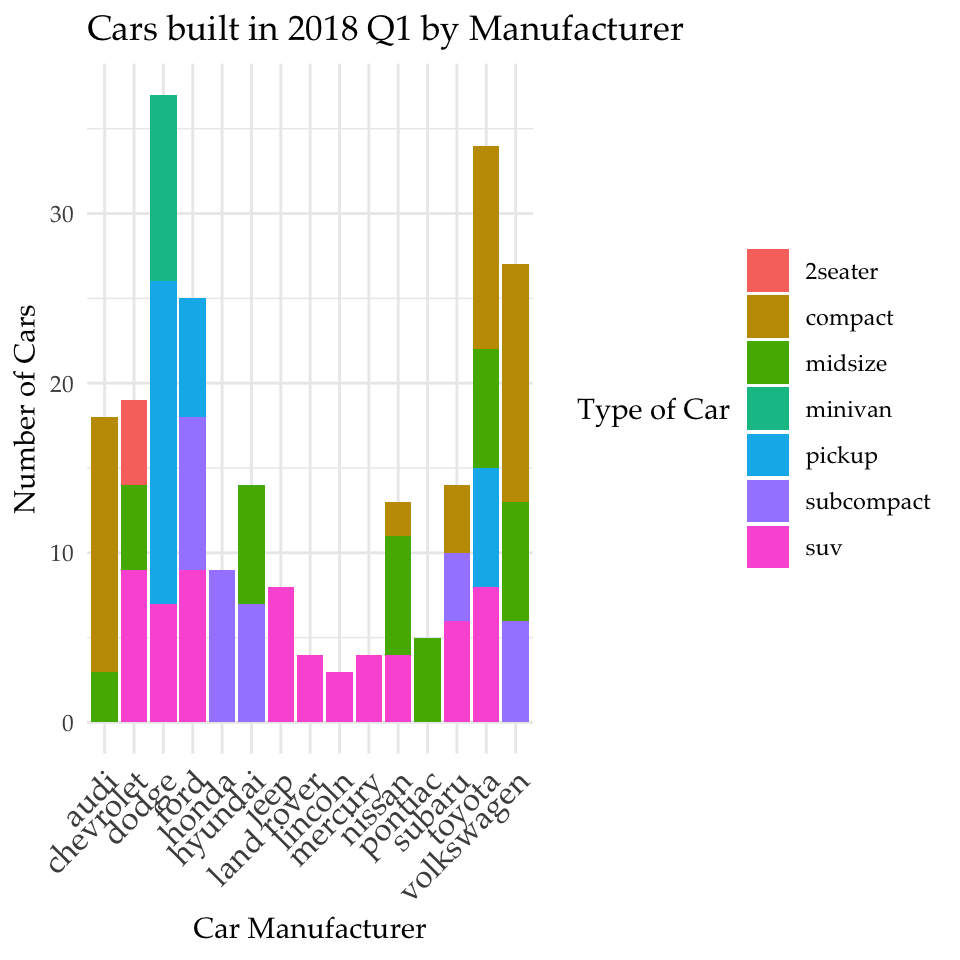

```r
ggplot(mpg) +
  geom_bar(aes(x=manufacturer, fill = class)) +
  xlab('Car Manufacturer') +
  ylab('Number of Cars' ) +
  ggtitle('Cars built in 2018 Q1 by Manufacturer') +
  theme_minimal()+
  theme(axis.text.x = element_text(size = 12, angle = 45, hjust = 1), text = element_text(family ='Palatino' )) +
  guides(fill = guide_legend(title = 'Type of Car', title.position = 'left'))
```

- while the text of legend cannot be changed inside theme, the position can be

## colors in R

- color palettes refer the to the set of colors you use within your plot.
- choosing the right color scheme for plot is an under appreciated, but crucial step.

```r
length(colors())
```

```
## [1] 657
```

- there are 657 distinct colors (though 200 of these are different shades of grey)

## What considerations should go into picking a color

- There’s been a lot research on what types of colors are best for plots
- TLDR - plots using color work best when there are *divergent* colors.
- This can be especially difficult when choosing a continuous fill, because certain colors don’t work well as a gradient
- Consider the following palette

## blues

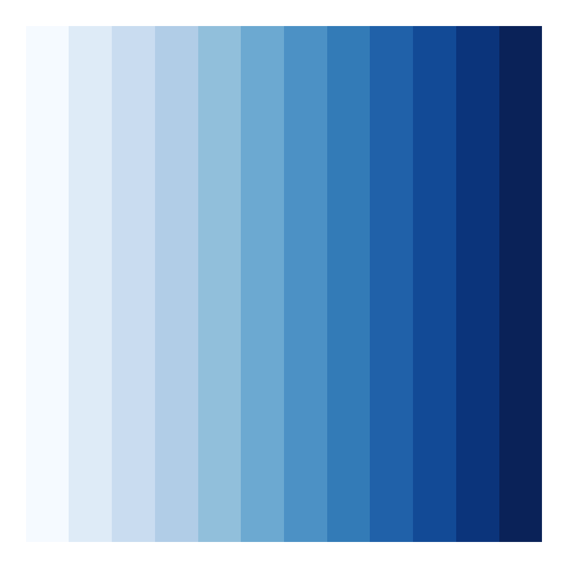

```r
plot_pal(cols =pals::brewer.blues(12))
```

## two color gradients

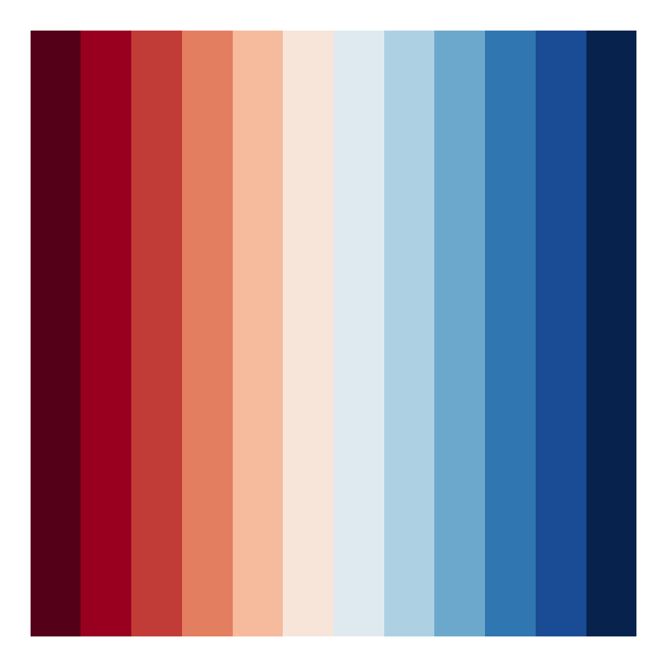

```r
plot_pal(pals::brewer.rdbu(12) )
```

## three color gradients - `viridis`

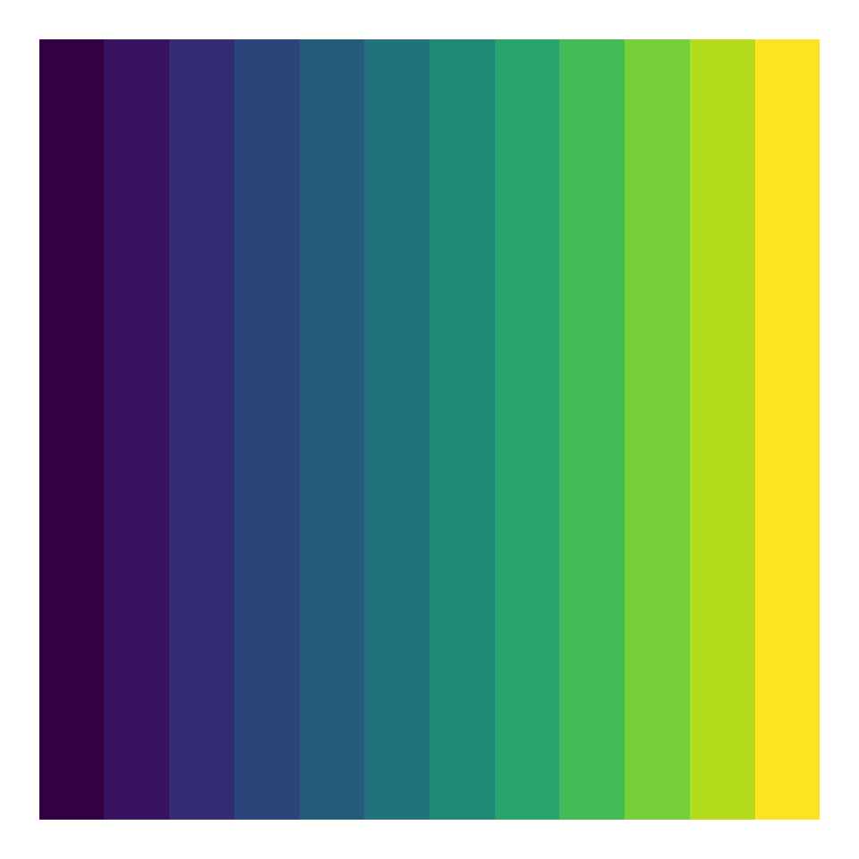

```r
plot_pal(pals::viridis(12))
```

## three color gradients - `magma`

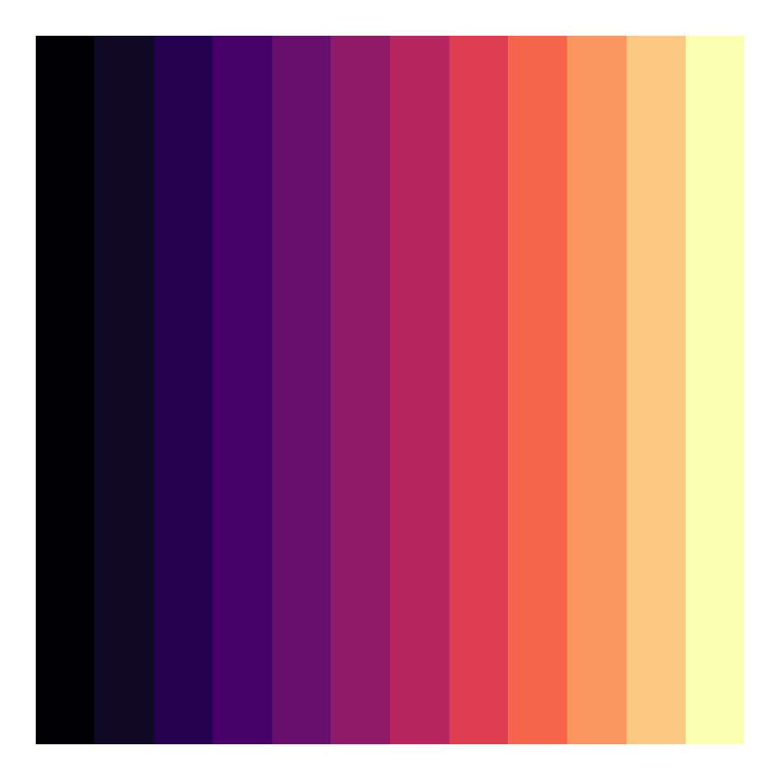

```r
plot_pal(pals::magma(12))
```

## three color gradients

- Use three color scales work best for almost all color gradients, and are the most distinguishable
- these two specific scales in particular, `viridis` and `magma`

## four color gradients

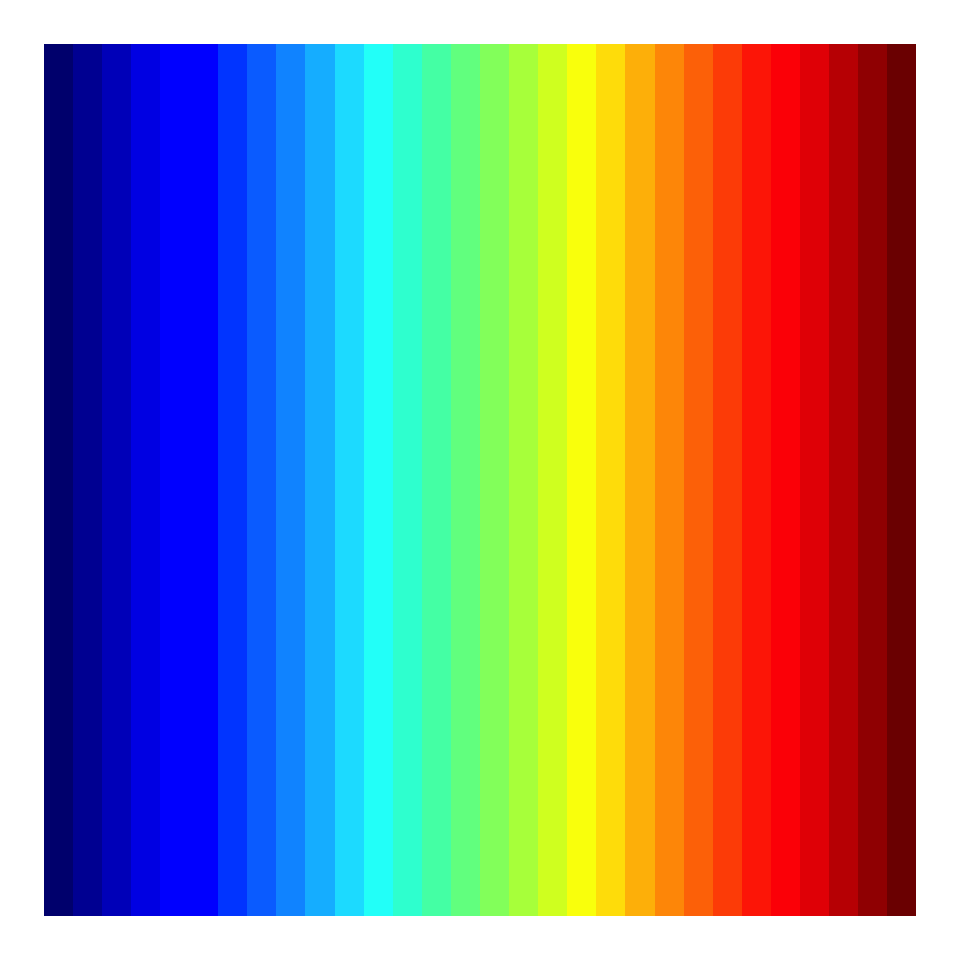

```r
plot_pal(pals::jet(30))
```

- the four color gradient looks cool and is tempting use, but its a little too busy.

## useful packages to generate color palettes

- the `RColorBrewer` package has arranged some of these into useful palettes

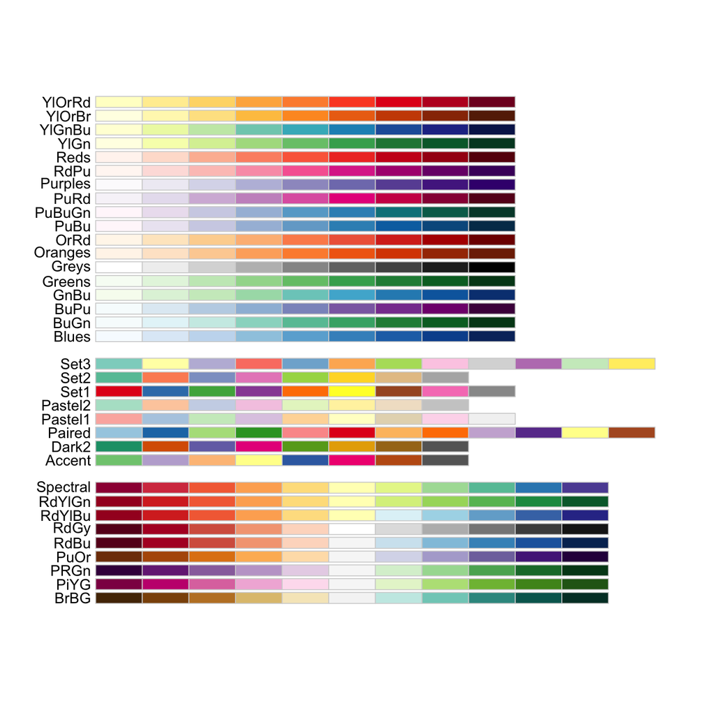

```r
library(RColorBrewer)

RColorBrewer::display.brewer.all()
```

the `pals` package - the `pals` package contains the most extensive set of color palettes and contains over a hundred palettes -the `Alphabet palette` the largest set distinct colors for discrete data

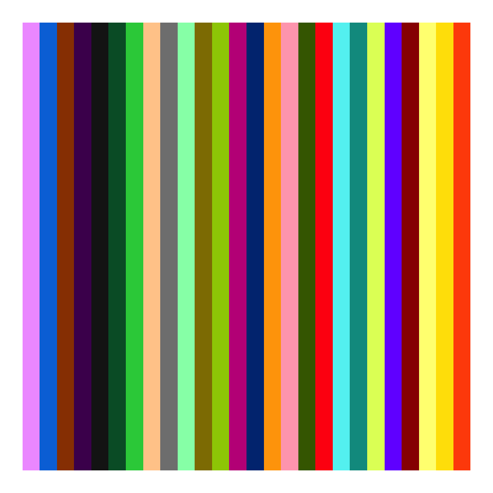

```r
library(pals)
print(plot_pal(alphabet()))
```

## using palettes functions

- all functions to generate a color palette function roughly the same way. Select a palette, and provide a number of colors to generate. A list of colors, specified in hex format is returned.
- when using the `pals` package, each palette is its own function and requires only the number of colors

```r
alphabet(4)
```

```
##  amethyst      blue   caramel    damson
## "#F0A0FF" "#0075DC" "#993F00" "#4C005C"
```

## using color palettes within ggplot

- default

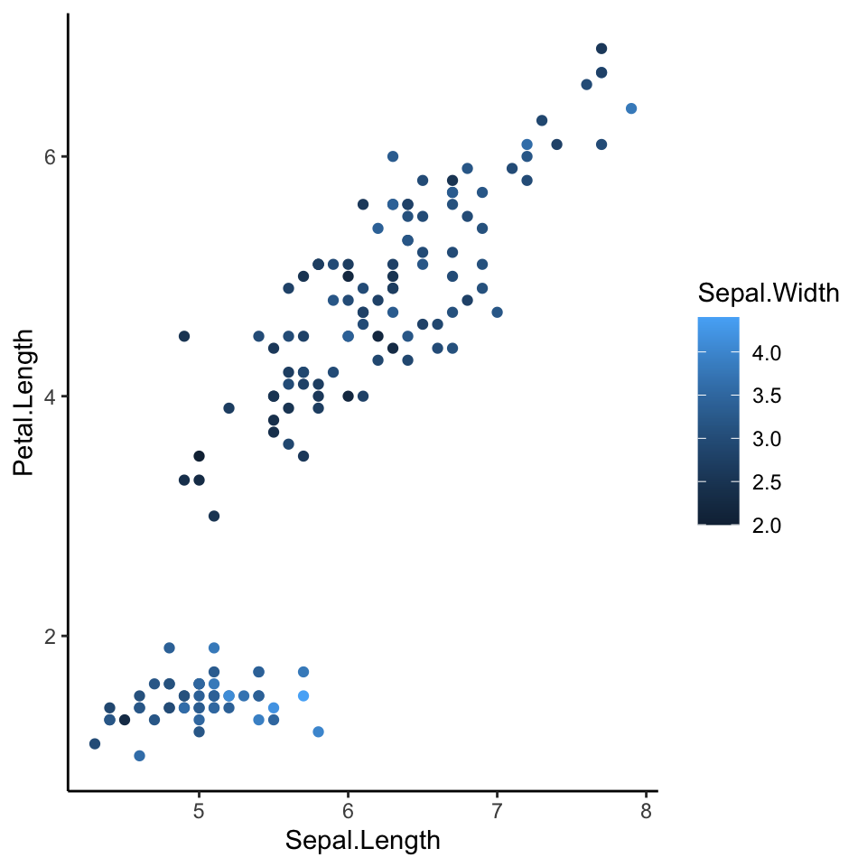

```r
ggplot(iris)  +
  geom_point(aes(x=Sepal.Length, Petal.Length, color = Sepal.Width))+
  theme_classic()
```

## using color palettes within ggplot

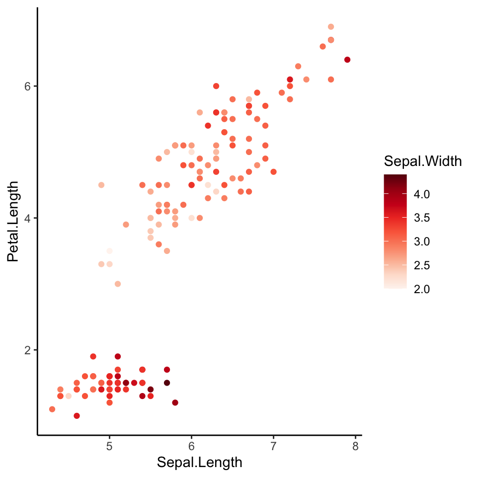

```r
ggplot(iris)  +
  geom_point(aes(x=Sepal.Length, Petal.Length, color = Sepal.Width))+
  scale_color_gradientn(colors = pals::brewer.reds(100))+
  theme_classic()
```

## the `scale_...` functions

- all `scale_...` functions have roughly the same format "scale__method"

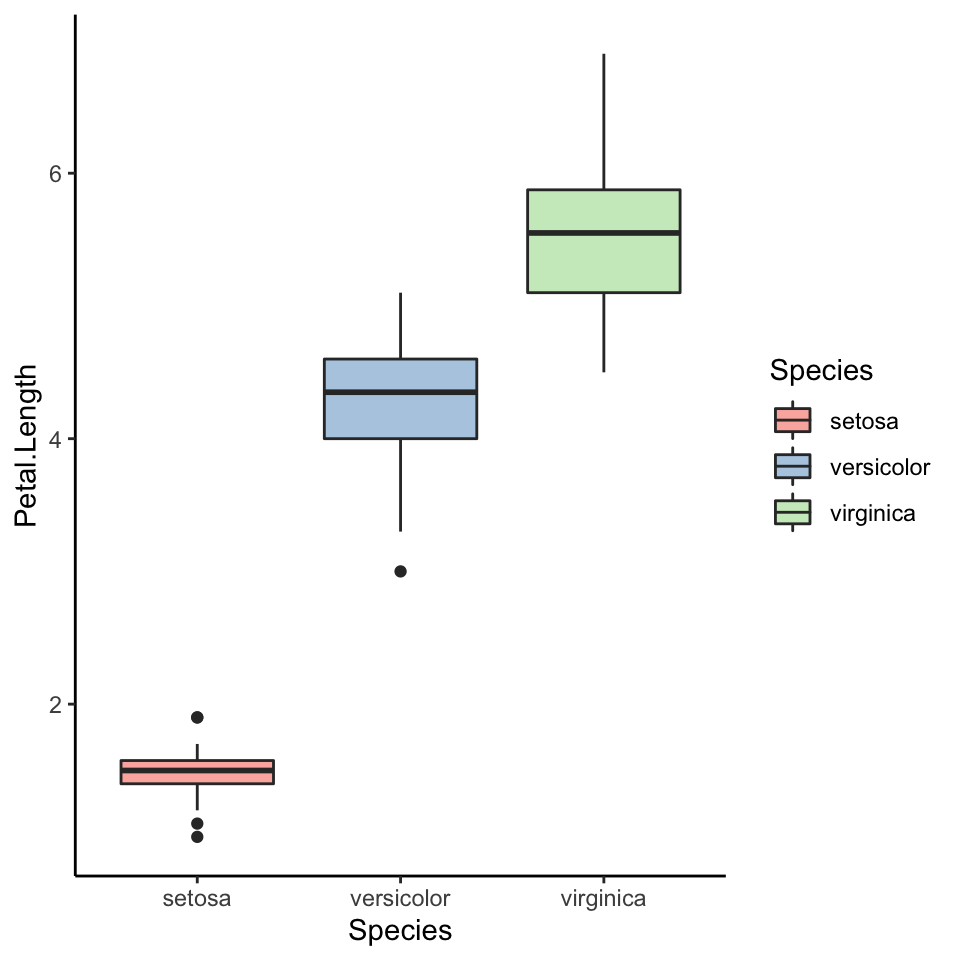

```r
pal = RColorBrewer::brewer.pal(3, 'Pastel1')
ggplot(iris)  +
  geom_boxplot(aes(x=Species, y=Petal.Length, fill = Species))+
  scale_fill_discrete(type = pal)+
  theme_classic()
```

## quick note about using discrete scales from the `pals` package

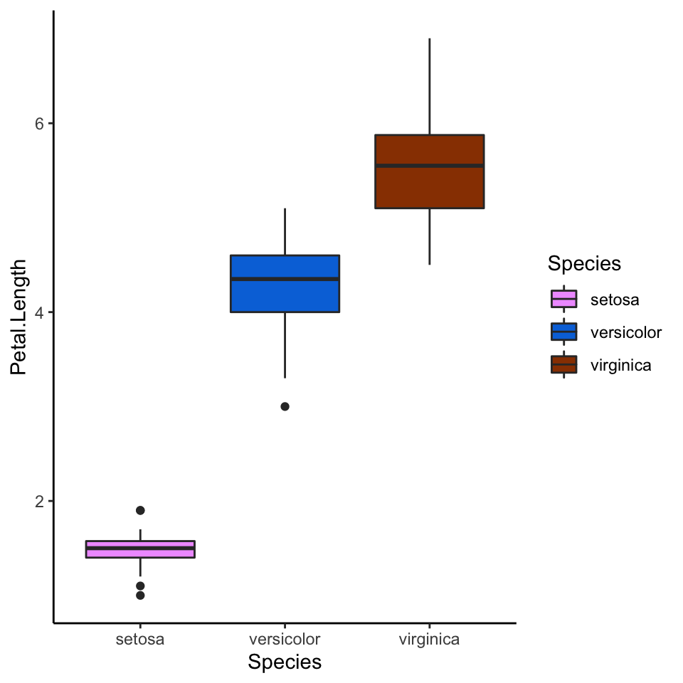

```r
pal = pals::alphabet()
names(pal) <- NULL
ggplot(iris)  +
  geom_boxplot(aes(x=Species, y=Petal.Length, fill = Species))+
  scale_fill_discrete(type = pal)+
  theme_classic()
```

## the `scale_...` functions

- always remember to set the right aesthetic

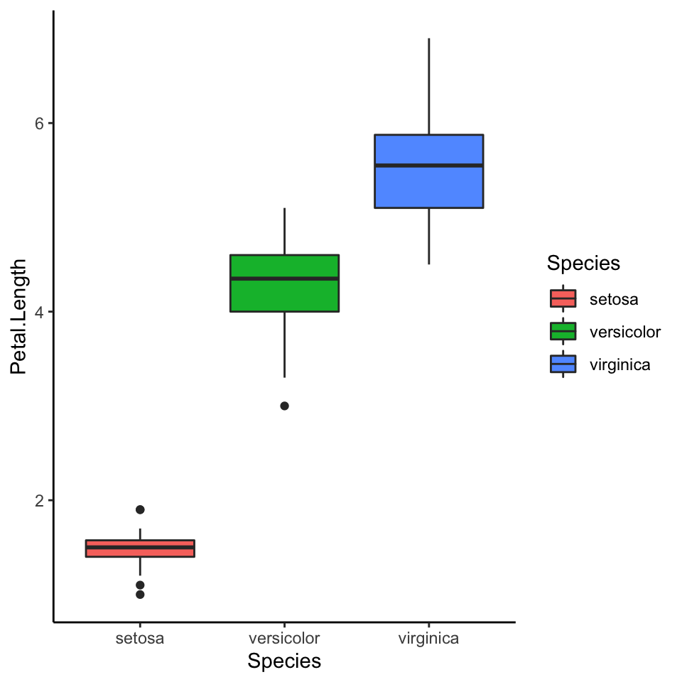

```r
pal = RColorBrewer::brewer.pal(3, 'Pastel1')
ggplot(iris)  +
  geom_boxplot(aes(x=Species, y=Petal.Length, fill = Species))+
  scale_color_discrete(type = pal)+
  theme_classic()
```

## the `scale_...` functions

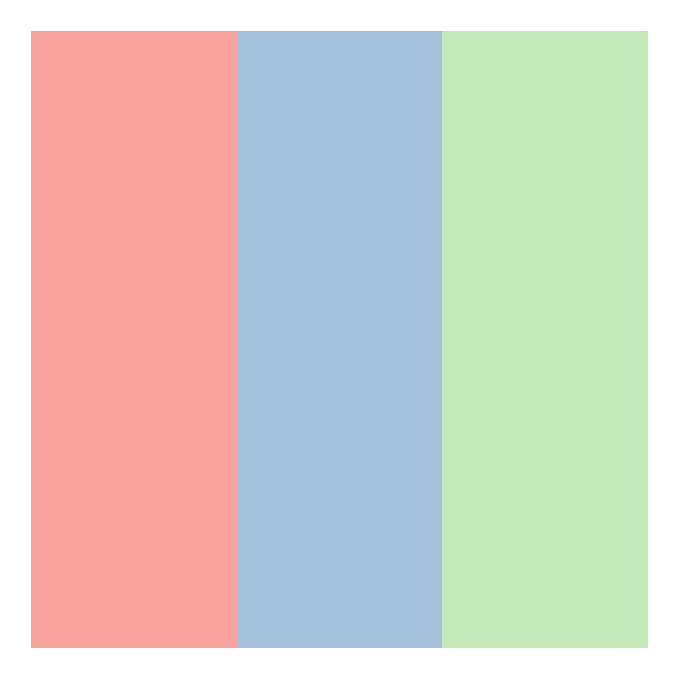

```r
plot_pal(pal)
```

## the `scale_...` functions

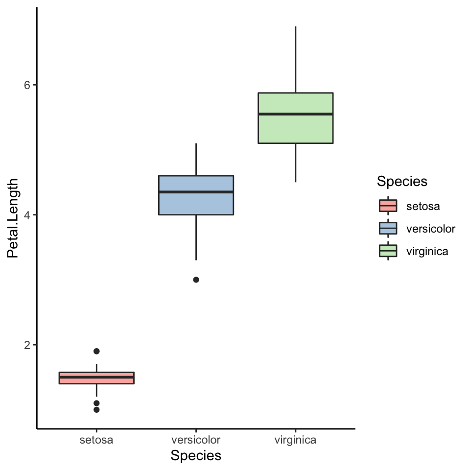

```r
ggplot(iris)  +
  geom_boxplot(aes(x=Species, y=Petal.Length, fill = Species))+
  scale_fill_discrete(type =pal)+
  theme_classic()
```

## the `scale_*_manual` functions

- a subset of the `scale` functions, these allow you to manually specify a mapping between an aesthetic and value being plotted, for a discrete scale

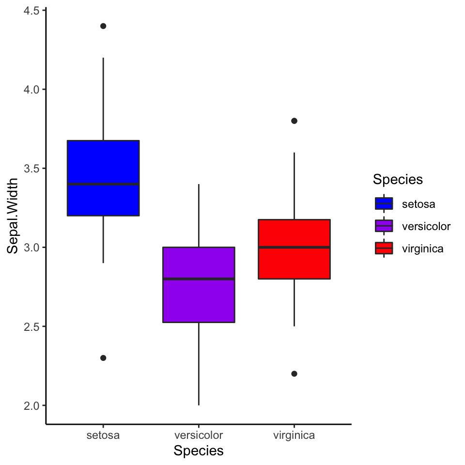

```r
col_vec <- c('setosa' = 'blue','versicolor' = 'purple',  'virginica' = 'red')
ggplot(iris) +
  geom_boxplot(aes(x= Species, y= Sepal.Width, fill = Species)) +
  scale_fill_manual(values = col_vec)  +
  theme_classic()
```

## the `scale_*_manual` functions

- using `scale_*_manual` is the best way to use a discrete color scale

## other aesthetics

- there are a couple other aesthetics we haven’t covered; some are specific to different plots

## size

- size is pretty straight forward, bigger number > bigger size

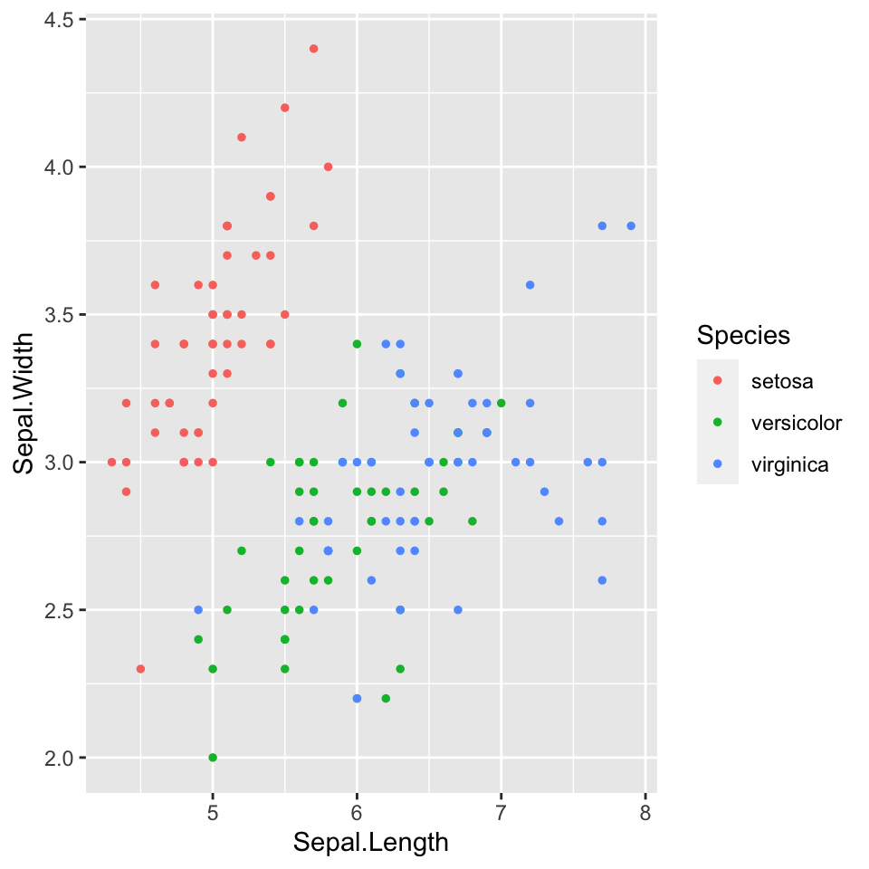

```r
ggplot(iris , aes(x=Sepal.Length, y=Sepal.Width, color = Species)) +
  geom_point(size = 1)
```

## size

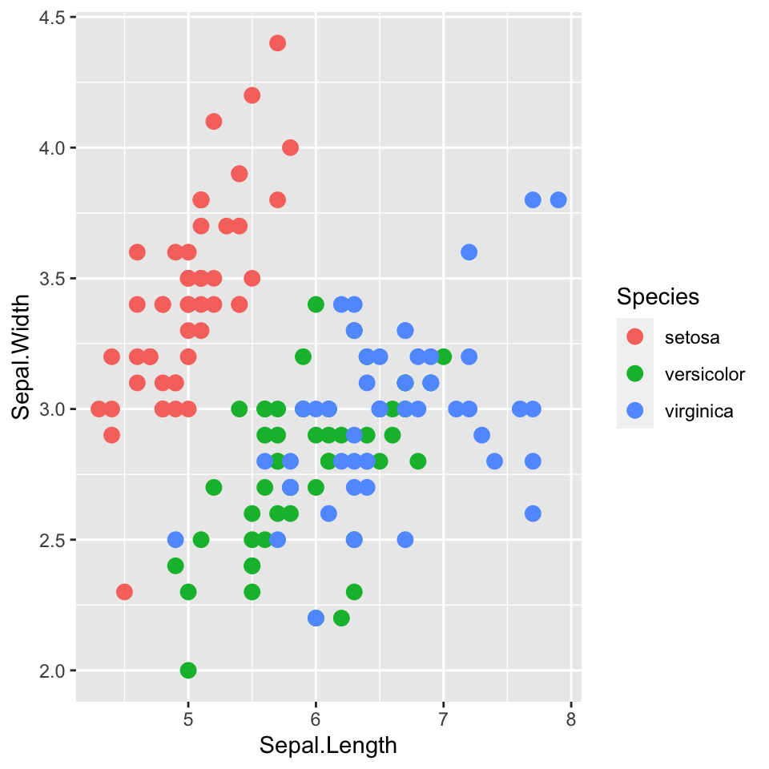

```r
ggplot(iris , aes(x=Sepal.Length, y=Sepal.Width, color = Species)) +
  geom_point(size = 3)
```

## alpha

- alpha controls the transparency of geoms, and is between 0(translucent) and 1(solid fill)

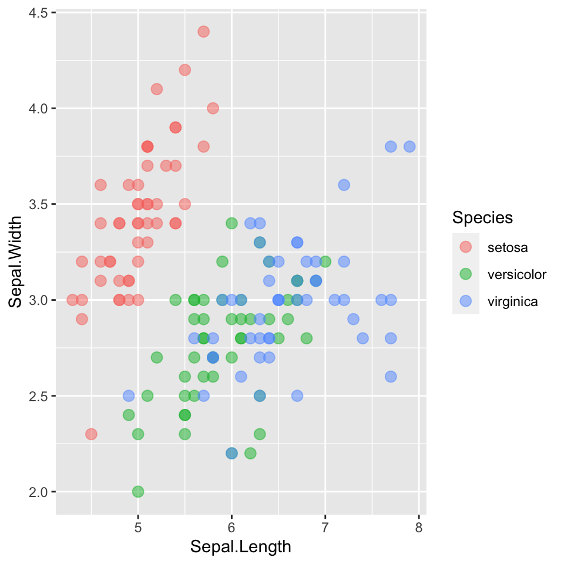

```r
ggplot(iris , aes(x=Sepal.Length, y=Sepal.Width, color = Species)) +
  geom_point(size = 3, alpha = .5)
```

## width

- width is an example of an aesthetic specific to a few geoms `geom_boxplot`, `geom_bar`, and `geom_boxplot`, to name a few

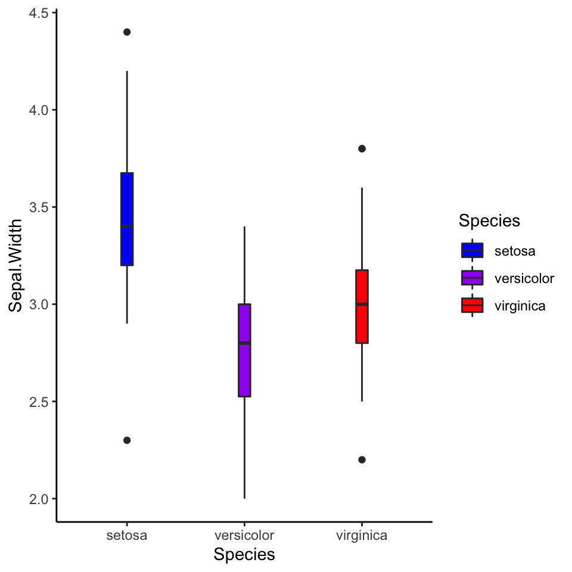

```r
ggplot(iris) +
  geom_boxplot(aes(x= Species, y= Sepal.Width, fill = Species), width = .1) +
  scale_fill_manual(values = col_vec)  +
  theme_classic()
```

## width

- always a good idea to spend some time looking through the documentation about what aesthetics work for what geoms